# Assignment2

### e.

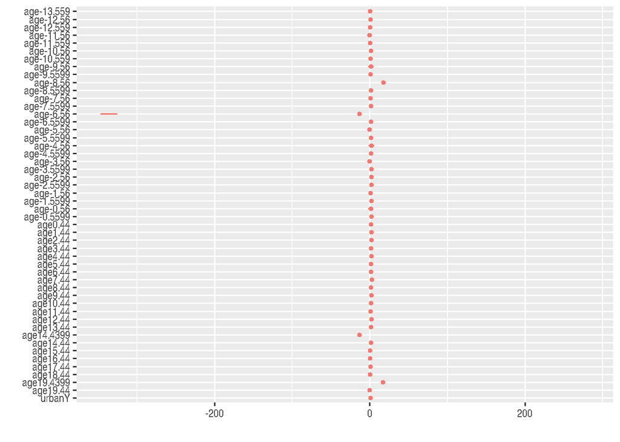

```r
dotwhisker::dwplot(model)
```

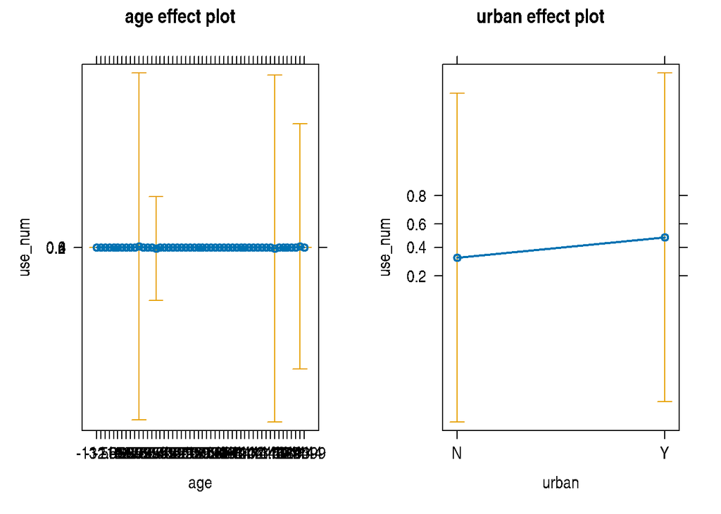

```r
effect<-effects::allEffects(model)
plot(effect)
```

## Question 2

```r
g_url <- "https://raw.githubusercontent.com/bbolker/mm_workshops/master/data/gopherdat2.csv"
g_data <- read.csv(g_url)
g_data$year<-as.factor(g_data$year)
```

### a.

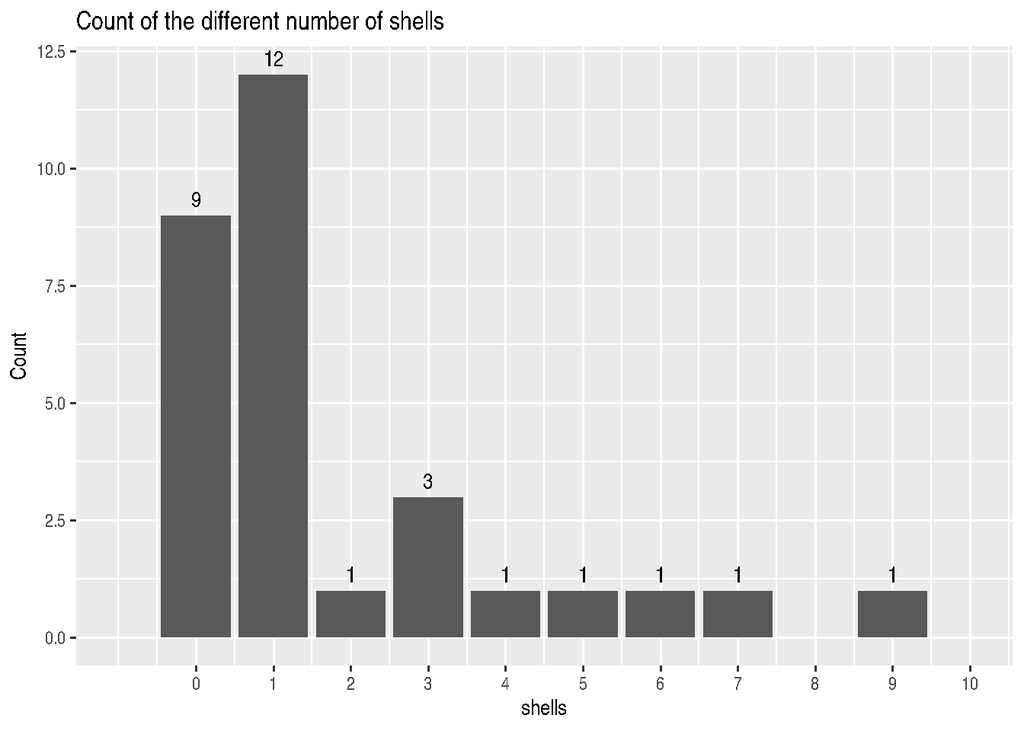

```r
g_data|>ggplot(aes(x=shells))+geom_bar()+geom_text(stat = "count", aes(label = ..count..), vjust = -0.5) +labs(title = "Count of the different number of shells",x="shells",y="Count")+scale_x_continuous(limits = c(-1, 10), breaks = seq(0,10,1))
```

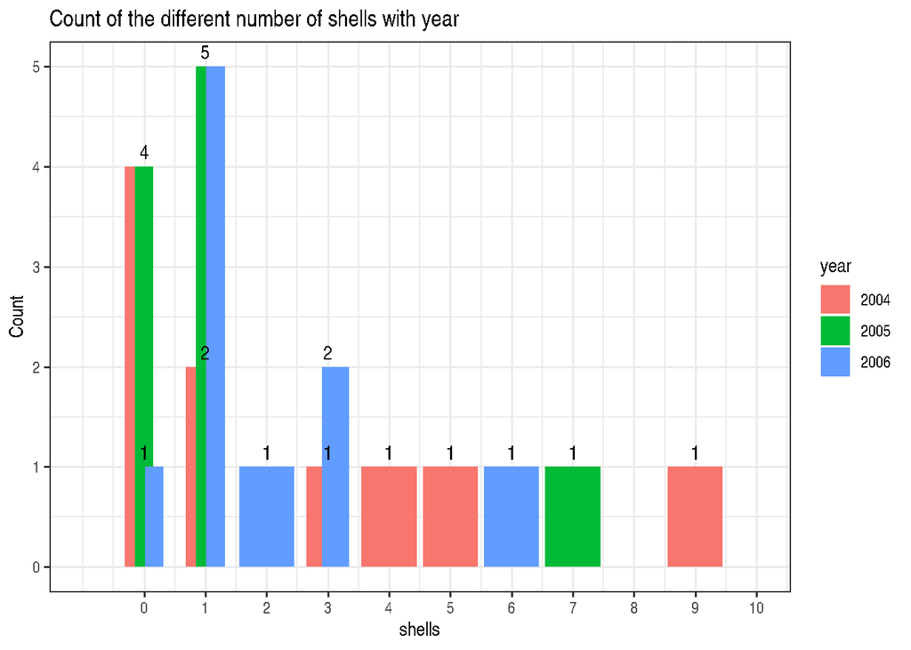

```r
g_data|>ggplot(aes(x=shells,fill = year))+geom_bar( position=position_dodge(width = 0.5))+theme_bw()+geom_text(stat = "count", aes(label = ..count..), vjust = -0.5) +labs(title = "Count of the different number of shells with year",x="shells",y="Count")+scale_x_continuous(limits = c(-1, 10), breaks = seq(0,10,1))
```

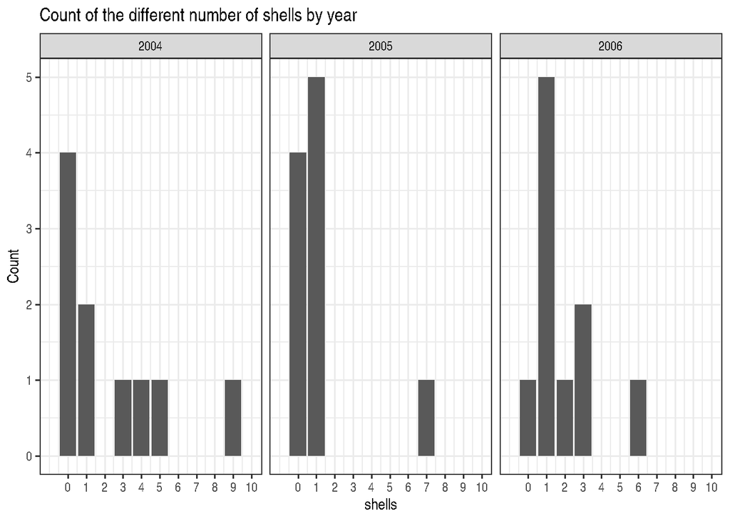

```r
g_data|> ggplot(aes(x = shells )) +geom_bar(
    position=position_dodge(width = 0.5))+
  theme_bw()+facet_wrap(~year)+labs(title = "Count of the different number of shells by year",x="shells",y="Count")+scale_x_continuous(limits = c(-1, 10), breaks = seq(0,10,1))
```

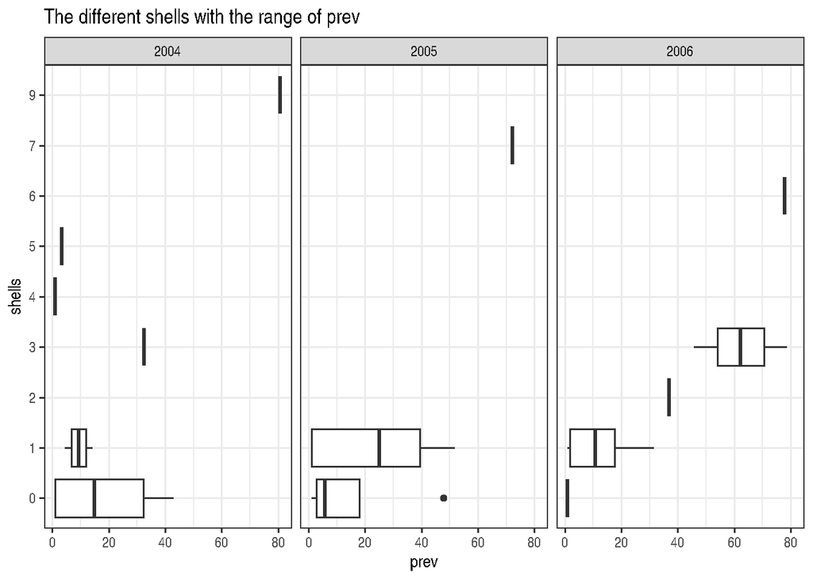

```r
g_data|>ggplot(aes(x=as.factor(shells),y=prev))+geom_boxplot()+facet_wrap(~year)+labs(title = "The different shells with the range of prev",x="shells",y="prev")+ coord_flip()+theme_bw()
```

We make the plotting with the year and prev. In 2024, not identity or clear relation between prev and shells. But in 2005 and 2006, it has the linear relation between prev and shells.

### b.

The rate as smapling sote area, the family as the Possion distribution. Offset is the log(area), non coefficienct with the model.

```r
g_model1_possion<-glm(shells~year+prev+offset(log(Area)),data=g_data,family = 'poisson')
g_model1quasi<-glm(shells~year+prev+offset(log(Area)),data=g_data,family =  quasipoisson)
g_model1_nb<-MASS::glm.nb(shells~year+prev+offset(log(Area)),data=g_data)
summary(g_model1_possion)
```

```
Call:
glm(formula = shells ~ year + prev + offset(log(Area)), family = "poisson",
    data = g_data)

Coefficients:
            Estimate Std. Error z value Pr(>|z|)
(Intercept) -3.19732    0.27850 -11.481  < 2e-16 ***
year2005    -0.64486    0.35639  -1.809   0.0704 .
year2006    -0.42876    0.31301  -1.370   0.1708
prev         0.02113    0.00431   4.903 9.44e-07 ***
---
Signif. codes:  0 '***' 0.001 '**' 0.01 '*' 0.05 '.' 0.1 ' ' 1

(Dispersion parameter for poisson family taken to be 1)

    Null deviance: 49.800  on 29  degrees of freedom
Residual deviance: 22.483  on 26  degrees of freedom
AIC: 84.337

Number of Fisher Scoring iterations: 5
```

```r
summary(g_model1quasi)
```

```
Call:
glm(formula = shells ~ year + prev + offset(log(Area)), family = quasipoisson,
    data = g_data)

Coefficients:
             Estimate Std. Error t value Pr(>|t|)
(Intercept) -3.197317   0.256981 -12.442 1.87e-12 ***
year2005    -0.644858   0.328853  -1.961   0.0607 .
year2006    -0.428759   0.288828  -1.484   0.1497
prev         0.021134   0.003977   5.313 1.47e-05 ***
---
Signif. codes:  0 '***' 0.001 '**' 0.01 '*' 0.05 '.' 0.1 ' ' 1

(Dispersion parameter for quasipoisson family taken to be 0.8514408)

    Null deviance: 49.800  on 29  degrees of freedom
Residual deviance: 22.483  on 26  degrees of freedom
AIC: NA

Number of Fisher Scoring iterations: 5
```

```r
summary(g_model1_nb)
```

```
Call:
MASS::glm.nb(formula = shells ~ year + prev + offset(log(Area)),
    data = g_data, init.theta = 19672.63258, link = log)

Coefficients:
             Estimate Std. Error z value Pr(>|z|)
(Intercept) -3.197315   0.278515 -11.480  < 2e-16 ***
year2005    -0.644898   0.356420  -1.809   0.0704 .
year2006    -0.428754   0.313050  -1.370   0.1708
prev         0.021134   0.004311   4.902 9.47e-07 ***
---
Signif. codes:  0 '***' 0.001 '**' 0.01 '*' 0.05 '.' 0.1 ' ' 1

(Dispersion parameter for Negative Binomial(19672.63) family taken to be 1)

    Null deviance: 49.794  on 29  degrees of freedom
Residual deviance: 22.481  on 26  degrees of freedom
AIC: 86.338

Number of Fisher Scoring iterations: 1

              Theta:  19673
          Std. Err.:  325479
Warning while fitting theta: iteration limit reached

 2 x log-likelihood:  -76.338
```

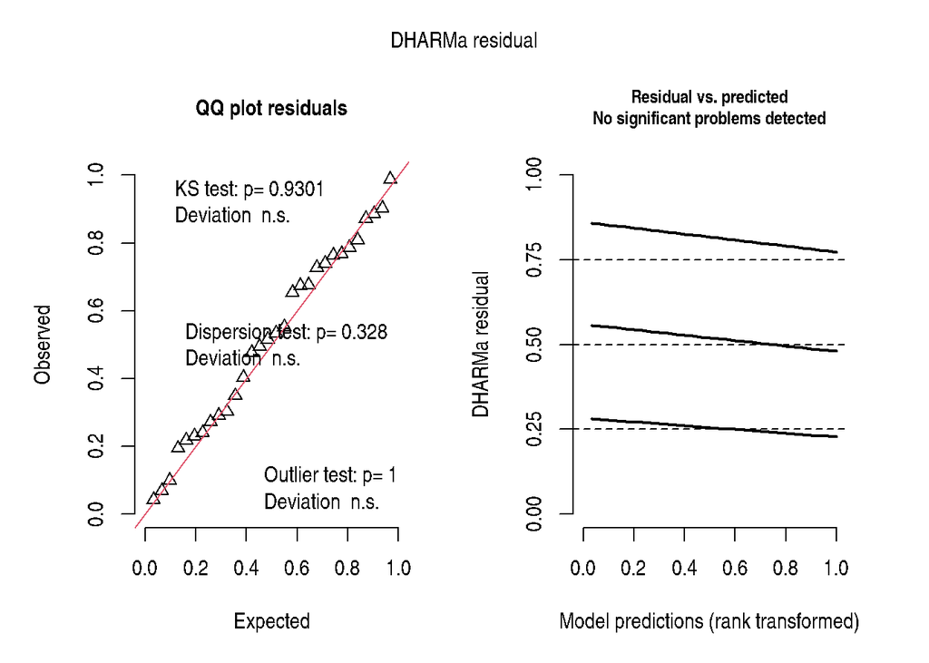

```
Object of Class DHARMa with simulated residuals based on 250 simulations with refit = FALSE . See ?DHARMa::simulateResiduals for help.

Scaled residual values: 0.04206502 0.5330109 0.5520363 0.7272805 0.5158833 0.8087703 0.2396851 0.7629875 0.8864874 0.348945 0.8709893 0.6529203 0.2713743 0.09904355 0.7860565 0.9881371 0.7388388 0.6747742 0.2901445 0.1941966 ...
```

```r
DHARMa::simulateResiduals(g_model1_possion,plot = TRUE)
```

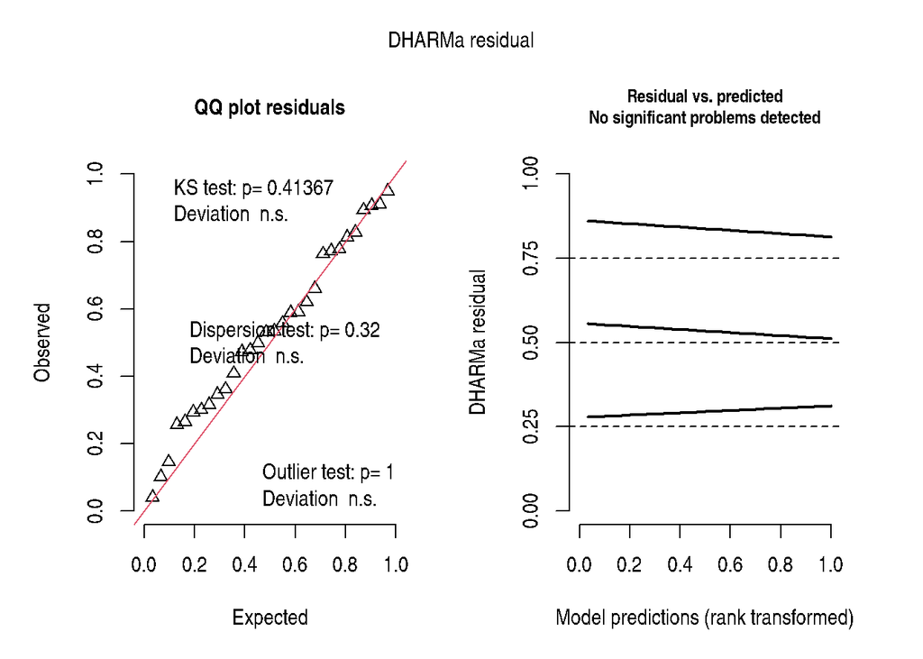

```
Object of Class DHARMa with simulated residuals based on 250 simulations with refit = FALSE . See ?DHARMa::simulateResiduals for help.

Scaled residual values: 0.1453553 0.04019381 0.5904405 0.7768138 0.659639 0.7628382 0.2999622 0.8274914 0.8133034 0.4080821 0.9097385 0.5568163 0.1014421 0.4994927 0.772393 0.9499679 0.5303545 0.5886005 0.3157332 0.2563053 ...
```

```r
DHARMa::simulateResiduals(g_model1_nb,plot = TRUE)
```

```r
pearson1<-sum((g_data$shells-g_model1_possion$fitted.values)^2/g_model1_possion$fitted.values)
disperson_pareameter1<-pearson1/g_model1_possion$df.residual
pearson2<-sum((g_data$shells-g_model1quasi$fitted.values)^2/g_model1quasi$fitted.values)
disperson_pareameter2<-pearson1/g_model1quasi$df.residual

sum(resid(g_model1quasi, type = "pearson")^2)/g_model1quasi$df.residual
```

```
[1] 0.8514406
```

We choose the model1 with the possion distribution, and the dispersion parameter is less than 1, almost 0.85/0.86. Diagnosis by two plots, it’s the good choice.

### c.

```r
g_model2_poisson<-bbmle::mle2(
  shells~ dpois(lambda=exp(log_lambda)),
  parameters = list(log_lambda~year+prev+offset(log(Area))),
  data = g_data,
  start = list(log_lambda=1))
```

### d.

```r
log_possion<-function(beta0=1,beta1=1,beta2=1,beta3=1){
  model_matrix<-model.matrix(~year+prev)
  linear_relation<-model_matrix%*%c(beta0,beta1,beta2,beta3)
  lambda<-exp(linear_relation)
  result<- -sum(stats::dpois(shells,lambda,log = TRUE))
  result
}
g_modelmlepossion<-bbmle::mle2(log_possion,data = g_data)
```

### e.

```r
g1<-g_model1_possion$coefficients
g2<-g_model2_poisson@coef
g3<-g_modelmlepossion@coef
parameter_compare<-data.frame(GLM=g1,MLE_inter=g2,MLE=g3)
parameter_compare
```

```
                    GLM   MLE_inter         MLE
(Intercept) -3.19731743  0.06033215  0.06105967
year2005    -0.64485763 -0.72034268 -0.72025454
year2006    -0.42875881 -0.46031147 -0.45996355
prev         0.02113395  0.02523674  0.02521959
```

### f.

```r
CI_GLE<-confint(g_model1_possion)

sd<-sqrt(diag(g_model2_poisson@vcov))
Mle_CI_min<-g_model2_poisson@coef-qnorm(1-0.05/2)*sd
Mle_CI_max<-g_model2_poisson@coef+qnorm(1-0.5/2)*sd
CI_MLE<-c(Mle_CI_min,Mle_CI_max)

sd2<-sqrt(diag(g_modelmlepossion@vcov))
Mle2_CI_min<-g_modelmlepossion@coef-qnorm(1-0.05/2)*sd
Mle2_CI_max<-g_modelmlepossion@coef+qnorm(1-0.5/2)*sd
CI_MLE2<-c(Mle2_CI_min,Mle2_CI_max)

CI_compare<-list(GLM=CI_GLE,MLE1=CI_MLE,MLE2=CI_MLE2)
CI_compare
```

```
$GLM
                  2.5 %      97.5 %
(Intercept) -3.78047101 -2.68513102
year2005    -1.37646427  0.03521203
year2006    -1.05249570  0.18368304
prev         0.01272002  0.02969948

$MLE1
log_lambda.(Intercept)    log_lambda.year2005    log_lambda.year2006
           -0.49909016            -1.41837599            -1.07530660
       log_lambda.prev log_lambda.(Intercept)    log_lambda.year2005
            0.01614114             0.25284825            -0.48012586
   log_lambda.year2006        log_lambda.prev
           -0.24867090             0.02836684

$MLE2
      beta0       beta1       beta2       beta3       beta0       beta1
-0.49836264 -1.41828785 -1.07495868  0.01612400  0.25357577 -0.48003772
      beta2       beta3
-0.24832297  0.02834969
```

## Question 3

As the binary “HG” is the response variable and select the category “NV” and continous “EH” with the predictor variables.

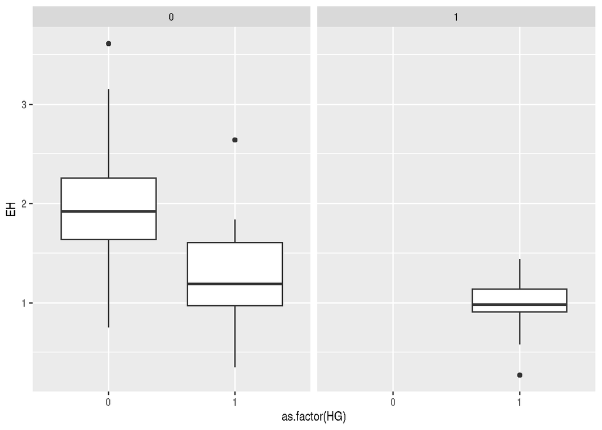

```r
e_data<-brglm2::endometrial
e_data$NV<-as.factor(e_data$NV)
e_data|>ggplot2::ggplot(aes(x=as.factor(HG),y=EH))+geom_boxplot()+facet_wrap(~NV)
```

From the plottings and find that the variable “NV” has the vital influence on the “HG” and the “EH” exists the effect whrn “NV”=0.

```r
e_glm<-glm(HG~NV+EH,data = e_data,family = "binomial")
summary(e_glm)
```

```
Call:
glm(formula = HG ~ NV + EH, family = "binomial", data = e_data)

Coefficients:
             Estimate Std. Error z value Pr(>|z|)
(Intercept)    3.4201     1.2696   2.694 0.007062 **
NV1           17.9894  1738.8255   0.010 0.991745
EH            -2.7891     0.8226  -3.391 0.000697 ***
---
Signif. codes:  0 '***' 0.001 '**' 0.01 '*' 0.05 '.' 0.1 ' ' 1

(Dispersion parameter for binomial family taken to be 1)

    Null deviance: 104.903  on 78  degrees of freedom
Residual deviance:  56.378  on 76  degrees of freedom
AIC: 62.378

Number of Fisher Scoring iterations: 17
```

```r
Disparameter_1<-sum(resid(e_glm,"pearson")^2)/e_glm$df.residual
Disparameter_1
```

```
[1] 1.234006
```

```r
#Overdispersion, more accurate model

e_bayes<-arm::bayesglm(HG~NV+EH, family = "binomial",data = e_data)
summary(e_bayes)
```

```
Call:
arm::bayesglm(formula = HG ~ NV + EH, family = "binomial", data = e_data)

Coefficients:
            Estimate Std. Error z value Pr(>|z|)
(Intercept)   3.1220     1.1431   2.731 0.006313 **
NV1           3.1671     1.5555   2.036 0.041746 *
EH           -2.5653     0.7297  -3.516 0.000439 ***
---
Signif. codes:  0 '***' 0.001 '**' 0.01 '*' 0.05 '.' 0.1 ' ' 1

(Dispersion parameter for binomial family taken to be 1)

    Null deviance: 104.903  on 78  degrees of freedom
Residual deviance:  57.154  on 76  degrees of freedom
AIC: 63.154

Number of Fisher Scoring iterations: 20
```

```r
Disparameter_2<-sum(resid(e_bayes,"pearson")^2)/e_glm$df.residual
Disparameter_2
```

```
[1] 1.050757
```

```r
# better than first model

e_glm2<-glm(HG~NV+EH,family = "binomial", method = "brglmFit",data = e_data)
summary(e_glm2)
```

```
Call:
glm(formula = HG ~ NV + EH, family = "binomial", data = e_data,
    method = "brglmFit")

Deviance Residuals:
    Min       1Q   Median       3Q      Max
-1.7112  -0.6255  -0.3401   0.3112   2.7193

Coefficients:
            Estimate Std. Error z value Pr(>|z|)
(Intercept)   3.1349     1.2089   2.593 0.009511 **
NV1           2.8474     1.5790   1.803 0.071343 .
EH           -2.5785     0.7741  -3.331 0.000865 ***
---
Signif. codes:  0 '***' 0.001 '**' 0.01 '*' 0.05 '.' 0.1 ' ' 1

(Dispersion parameter for binomial family taken to be 1)

    Null deviance: 104.903  on 78  degrees of freedom
Residual deviance:  57.394  on 76  degrees of freedom
AIC:  63.394

Type of estimator: AS_mixed (mixed bias-reducing adjusted score equations)
Number of Fisher Scoring iterations: 7
```

```r
Disparameter_3<-sum(resid(e_glm2)^2)/e_glm2$df.residual
```

### 1).Estimates

```r
estimate<-data.frame(GLE=e_glm$coefficients,Bayesglm=e_bayes$coefficients,GLM2=e_glm2$coefficients)
estimate
```

```
                  GLE  Bayesglm      GLM2
(Intercept)  3.420084  3.121955  3.134858
NV1         17.989388  3.167128  2.847357
EH          -2.789140 -2.565329 -2.578459
```

### 2). Wald and likelihood profile CI

We can’t get the appropriate profile CI of glm1 and bayesglm. But we could get the Wald CI with the three different models.

```r
wald_CI<-list(GLM=stats::confint.default(e_glm),Bayesglm=stats::confint.default(e_bayes),GLM2=stats::confint.default(e_glm2))
wald_CI
```

```
$GLM
                    2.5 %      97.5 %
(Intercept)     0.9318003    5.908367
NV1         -3390.0459485 3426.024725
EH             -4.4014294   -1.176851

$Bayesglm
                 2.5 %    97.5 %
(Intercept)  0.8814492  5.362461
NV1          0.1183379  6.215919
EH          -3.9954684 -1.135191

$GLM2
                 2.5 %    97.5 %
(Intercept)  0.7654455  5.504270
NV1         -0.2473899  5.942104
EH          -4.0956487 -1.061269
```

### 3). Wald likelihood ratio-test p-values

```r
P_value<-data.frame(GLM=Anova(e_glm,test="LR")$`Pr(>Chisq)`,Bayesglm=Anova(e_bayes,test="LR")$`Pr(>Chisq)`,GLM2=Anova(e_glm2,test="LR")$`Pr(>Chisq)`)
row.names(P_value)<-c("NV","EH")
P_value
```

```
            GLM     Bayesglm         GLM2
NV 0.0031848346 4.881108e-03 5.576041e-03
EH 0.0000135718 2.038562e-05 2.313087e-05
```

## Question 4

The response variable is “art”, and the predictor variable are “fem”,“kid5”,“ment”.

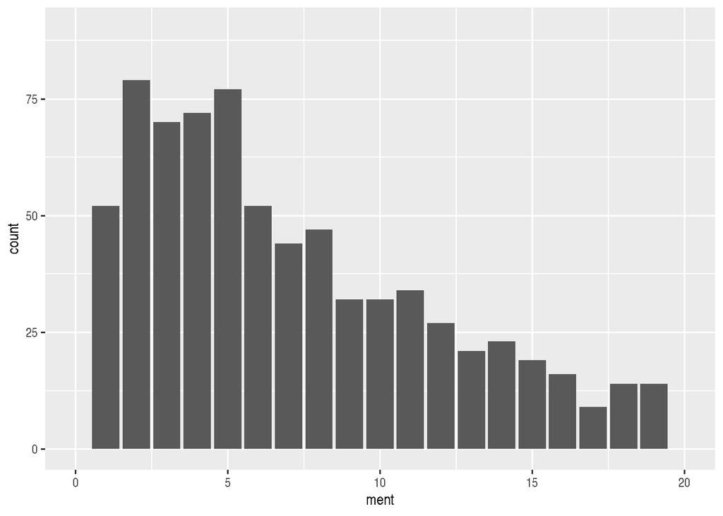

```r
b_data<-pscl::bioChemists
b_data$fem<-as.factor(b_data$fem)
b_data$kid5<-as.factor(b_data$kid5)
b_model<-MASS::glm.nb(art~fem+kid5+ment,data = b_data)

## let's build the functions of predictor variables, each type number of 125.
pro_kids<-rep(0,4)
pro_kids[1]<-round(nrow(b_data[b_data$kid5==0,])/nrow(b_data),2)+0.01
pro_kids[2]<-round(nrow(b_data[b_data$kid5==1,])/nrow(b_data),2)
pro_kids[3]<-round(nrow(b_data[b_data$kid5==2,])/nrow(b_data),2)
pro_kids[4]<-round(nrow(b_data[b_data$kid5==3,])/nrow(b_data),2)

b_data|>ggplot2::ggplot(aes(x=ment))+geom_bar()+xlim(0,20)
```

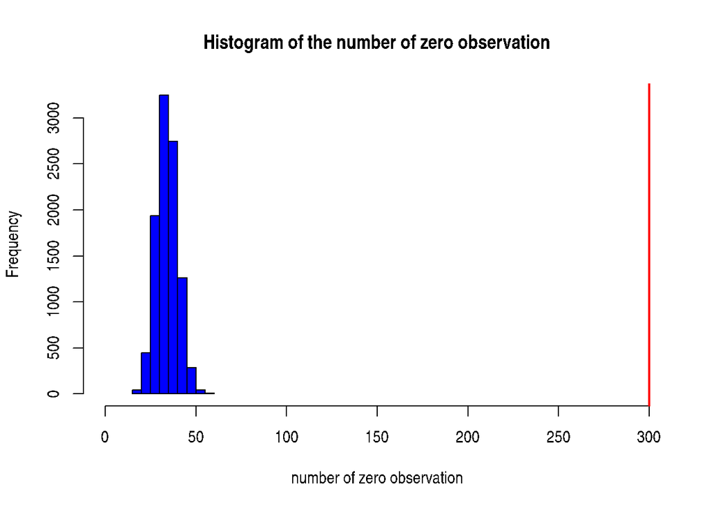

```r
est_lambda<-median(b_data$ment)
neg<-function(size,pro){
  -sum(dnbinom(ment,size,pro,log = TRUE))
}
est<-bbmle::mle2(
  neg,
  data = b_data,
  start = list(size=2,pro=0.2))

pro_gender<-0.5
pro_kids<-pro_kids
size<-est@coef[1]; pro<-est@coef[2]

## The functions of the simulation
simulation_once<-function(pro_gender,pro_kids,size,prob){
  fem<-rbinom(1000,1,pro_gender)
  fem[fem==0]<-"Men"
  fem[fem==1]<-"Women"

  kids_class<-c("0","1","2","3")
  kids<-sample(kids_class,size=1000,replace = TRUE,prob = pro_kids)

  ment<-rnbinom(n = 1000, size, prob)


  predict_datafram<-data.frame(fem=fem,kid5=kids,ment=ment)
  predict_datafram$fem<-as.factor(predict_datafram$fem)
  predict_datafram$kid5<-as.factor(predict_datafram$kid5)
  art<-as.integer(predict(b_model,predict_datafram,type = "response"))
  result<-length(art[art==0])
  result
}

simulation<-function(pro_gender,pro_kids,size,prob,times){
  number_zerobservation<-rep(0,times)
  for (i in 1:times) {
    number_zerobservation[i]<-simulation_once(pro_gender,pro_kids,size,prob)
  }
  number_zerobservation
}

## train and compare to the number of art==0 from the original data.
compare_original<-as.integer(nrow(b_data[b_data$art==0,])/nrow(b_data)*1000)


set.seed(1)
result<-simulation(0.5,pro_kids,size,pro,10000)
hist(result,xlab = "number of zero observation",main="Histogram of the number of zero observation",col="blue",border = "black",xlim = c(0,300))
abline(v=compare_original, col="red", lwd=2)
```

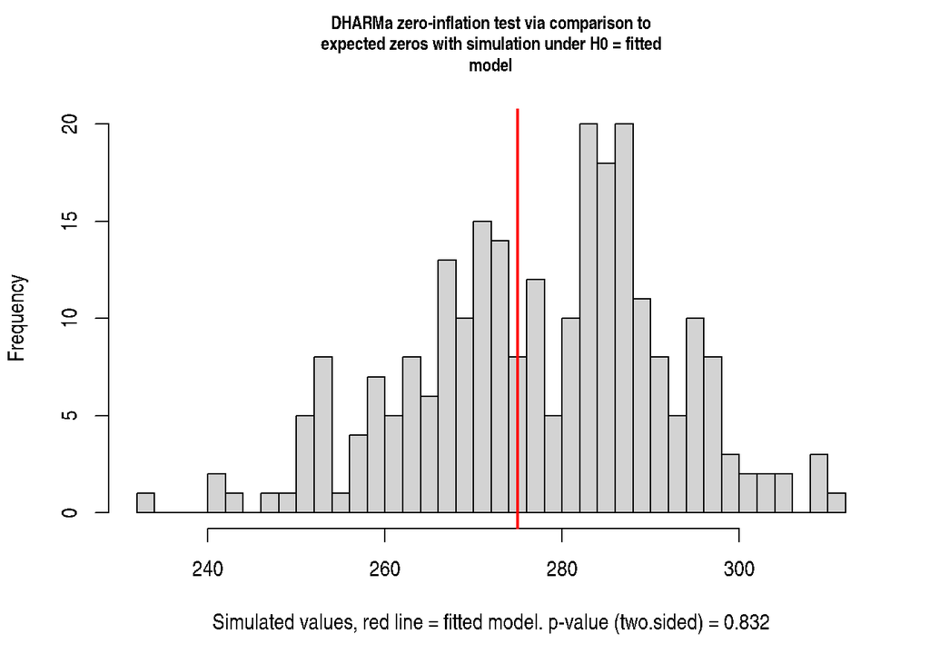

```
    DHARMa zero-inflation test via comparison to expected zeros with
    simulation under H0 = fitted model

data:  simulationOutput
ratioObsSim = 0.98894, p-value = 0.832
alternative hypothesis: two.sided
```

```r
DHARMa::testZeroInflation(b_model)
```

Actually, by the simulation result, the p value will be too small and it will be reject the H0 than the DHARMa fitted result.